# Problem statement :

**The Thera bank recently saw a steep decline in the number of users of their credit card**, **credit cards are a good source of income for banks because of different kinds of fees charged by the banks like annual fees**, **balance transfer fees, and cash advance fees, late payment fees, foreign transaction fees, and others**. **Some fees are charged to every user irrespective of usage, while others are charged under specified circumstances**. **Customers' leaving credit card services would lead the bank to loss, so the bank wants to analyze the data of customers and identify the customers who will leave their credit card services and the reason for same - so that the bank could improve upon those areas** .

```python
import numpy as np
import pandas as pd
import matplotlib.pyplot as plt
import seaborn as sns
!pip install category_encoders
import category_encoders as ce
from sklearn.model_selection import train_test_split
from sklearn.metrics import mean_absolute_error, mean_squared_error, r2_score
from sklearn.tree import DecisionTreeRegressor
from sklearn.model_selection import RandomizedSearchCV
from scipy.stats import randint
from sklearn.ensemble import RandomForestRegressor, GradientBoostingRegressor, AdaBoostRegressor, BaggingRegressor
from imblearn.over_sampling import RandomOverSampler
from collections import Counter
import warnings
warnings.filterwarnings('ignore')
```

```python
from google.colab import drive
drive.mount('/content/drive')
data = pd.read_csv("/content/drive/MyDrive/BankChurners.csv")
df = data
df.head(5)
```

|  | CLIENTNUM | Attrition_Flag | Customer_Age | Gender | Dependent_count | Education_Level | Marital_Status | Income_Category | Card_Category | Months_on_book | ... | Months_Inactive_12_mon | Contacts_Count_12_mon | Credit_Limit | Total_Revolving_Bal | Avg_Open_To_Buy | Total_Amt_Chng_Q4_Q1 | Total_Trans_Amt | Total_Trans_Ct | Total_Ct_Chng_Q4_Q1 | Avg_Utilization_Ratio |
| --- | --- | --- | --- | --- | --- | --- | --- | --- | --- | --- | --- | --- | --- | --- | --- | --- | --- | --- | --- | --- | --- |
| 0 | 768805383 | Existing Customer | 45 | M | 3 | High School | Married | $60K - $80K | Blue | 39 | ... | 1 | 3 | 12691.0 | 777 | 11914.0 | 1.335 | 1144 | 42 | 1.625 | 0.061 |
| 1 | 818770008 | Existing Customer | 49 | F | 5 | Graduate | Single | Less than $40K | Blue | 44 | ... | 1 | 2 | 8256.0 | 864 | 7392.0 | 1.541 | 1291 | 33 | 3.714 | 0.105 |
| 2 | 713982108 | Existing Customer | 51 | M | 3 | Graduate | Married | $80K - $120K | Blue | 36 | ... | 1 | 0 | 3418.0 | 0 | 3418.0 | 2.594 | 1887 | 20 | 2.333 | 0.000 |
| 3 | 769911858 | Existing Customer | 40 | F | 4 | High School | NaN | Less than $40K | Blue | 34 | ... | 4 | 1 | 3313.0 | 2517 | 796.0 | 1.405 | 1171 | 20 | 2.333 | 0.760 |
| 4 | 709106358 | Existing Customer | 40 | M | 3 | Uneducated | Married | $60K - $80K | Blue | 21 | ... | 1 | 0 | 4716.0 | 0 | 4716.0 | 2.175 | 816 | 28 | 2.500 | 0.000 |

5 rows × 21 columns

**Checking the shape of the dataset** :

```python
df.shape
```

```
(10127, 21)
```

The dataset has 10,127 rows and 21 columns

**Checking the data types of the columns for the dataset** :

```python
data.dtypes
```

|  | 0 |
| --- | --- |
| CLIENTNUM | int64 |
| Attrition_Flag | object |
| Customer_Age | int64 |
| Gender | object |
| Dependent_count | int64 |
| Education_Level | object |
| Marital_Status | object |
| Income_Category | object |
| Card_Category | object |
| Months_on_book | int64 |
| Total_Relationship_Count | int64 |
| Months_Inactive_12_mon | int64 |
| Contacts_Count_12_mon | int64 |
| Credit_Limit | float64 |
| Total_Revolving_Bal | int64 |
| Avg_Open_To_Buy | float64 |
| Total_Amt_Chng_Q4_Q1 | float64 |
| Total_Trans_Amt | int64 |
| Total_Trans_Ct | int64 |
| Total_Ct_Chng_Q4_Q1 | float64 |
| Avg_Utilization_Ratio | float64 |

**dtype:** object

**Checking for missing values** :

```python
#checking number of null values
missing_values = data.isnull().sum()
missing_percentage = (missing_values / len(data)) * 100
missing_summary = pd.DataFrame({'Missing Values': missing_values, 'Percentage (%)': missing_percentage})
print("Missing Values Summary:", missing_summary)
# Treatment based on missing value percentage
threshold = 50
columns_to_drop = missing_summary[missing_summary['Percentage (%)'] > threshold].index
data_cleaned = data.drop(columns=columns_to_drop, axis=1)
print("Columns dropped due to high missing values:", list(columns_to_drop))
for col in data_cleaned.select_dtypes(include=['float64', 'int64']).columns:
    if data_cleaned[col].isnull().sum() > 0:
        data_cleaned[col].fillna(data_cleaned[col].mean(), inplace=True)
for col in data_cleaned.select_dtypes(include=['object']).columns:
    if data_cleaned[col].isnull().sum() > 0:
        data_cleaned[col].fillna(data_cleaned[col].mode()[0], inplace=True)
print("Missing values after treatment:",data_cleaned.isnull().sum())
```

```
Missing Values Summary:                           Missing Values  Percentage (%)
CLIENTNUM                              0        0.000000
Attrition_Flag                         0        0.000000
Customer_Age                           0        0.000000
Gender                                 0        0.000000
Dependent_count                        0        0.000000
Education_Level                     1519       14.999506
Marital_Status                       749        7.396070
Income_Category                        0        0.000000
Card_Category                          0        0.000000
Months_on_book                         0        0.000000
Total_Relationship_Count               0        0.000000
Months_Inactive_12_mon                 0        0.000000
Contacts_Count_12_mon                  0        0.000000
Credit_Limit                           0        0.000000
Total_Revolving_Bal                    0        0.000000
Avg_Open_To_Buy                        0        0.000000
Total_Amt_Chng_Q4_Q1                   0        0.000000
Total_Trans_Amt                        0        0.000000
Total_Trans_Ct                         0        0.000000
Total_Ct_Chng_Q4_Q1                    0        0.000000
Avg_Utilization_Ratio                  0        0.000000
Columns dropped due to high missing values: []
Missing values after treatment: CLIENTNUM                   0
Attrition_Flag              0
Customer_Age                0
Gender                      0
Dependent_count             0
Education_Level             0
Marital_Status              0
Income_Category             0
Card_Category               0
Months_on_book              0
Total_Relationship_Count    0
Months_Inactive_12_mon      0
Contacts_Count_12_mon       0
Credit_Limit                0
Total_Revolving_Bal         0
Avg_Open_To_Buy             0
Total_Amt_Chng_Q4_Q1        0
Total_Trans_Amt             0
Total_Trans_Ct              0
Total_Ct_Chng_Q4_Q1         0
Avg_Utilization_Ratio       0
dtype: int64
```

**Statistical summary of the data** :

```python
df.describe()
```

|  | CLIENTNUM | Customer_Age | Dependent_count | Months_on_book | Total_Relationship_Count | Months_Inactive_12_mon | Contacts_Count_12_mon | Credit_Limit | Total_Revolving_Bal | Avg_Open_To_Buy | Total_Amt_Chng_Q4_Q1 | Total_Trans_Amt | Total_Trans_Ct | Total_Ct_Chng_Q4_Q1 | Avg_Utilization_Ratio |
| --- | --- | --- | --- | --- | --- | --- | --- | --- | --- | --- | --- | --- | --- | --- | --- |
| count | 1.012700e+04 | 10127.000000 | 10127.000000 | 10127.000000 | 10127.000000 | 10127.000000 | 10127.000000 | 10127.000000 | 10127.000000 | 10127.000000 | 10127.000000 | 10127.000000 | 10127.000000 | 10127.000000 | 10127.000000 |
| mean | 7.391776e+08 | 46.325960 | 2.346203 | 35.928409 | 3.812580 | 2.341167 | 2.455317 | 8631.953698 | 1162.814061 | 7469.139637 | 0.759941 | 4404.086304 | 64.858695 | 0.712222 | 0.274894 |
| std | 3.690378e+07 | 8.016814 | 1.298908 | 7.986416 | 1.554408 | 1.010622 | 1.106225 | 9088.776650 | 814.987335 | 9090.685324 | 0.219207 | 3397.129254 | 23.472570 | 0.238086 | 0.275691 |
| min | 7.080821e+08 | 26.000000 | 0.000000 | 13.000000 | 1.000000 | 0.000000 | 0.000000 | 1438.300000 | 0.000000 | 3.000000 | 0.000000 | 510.000000 | 10.000000 | 0.000000 | 0.000000 |
| 25% | 7.130368e+08 | 41.000000 | 1.000000 | 31.000000 | 3.000000 | 2.000000 | 2.000000 | 2555.000000 | 359.000000 | 1324.500000 | 0.631000 | 2155.500000 | 45.000000 | 0.582000 | 0.023000 |
| 50% | 7.179264e+08 | 46.000000 | 2.000000 | 36.000000 | 4.000000 | 2.000000 | 2.000000 | 4549.000000 | 1276.000000 | 3474.000000 | 0.736000 | 3899.000000 | 67.000000 | 0.702000 | 0.176000 |
| 75% | 7.731435e+08 | 52.000000 | 3.000000 | 40.000000 | 5.000000 | 3.000000 | 3.000000 | 11067.500000 | 1784.000000 | 9859.000000 | 0.859000 | 4741.000000 | 81.000000 | 0.818000 | 0.503000 |
| max | 8.283431e+08 | 73.000000 | 5.000000 | 56.000000 | 6.000000 | 6.000000 | 6.000000 | 34516.000000 | 2517.000000 | 34516.000000 | 3.397000 | 18484.000000 | 139.000000 | 3.714000 | 0.999000 |

**PERFORMING EDA TO ANALYSE THE DATA** :

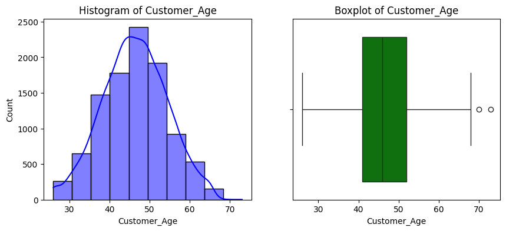

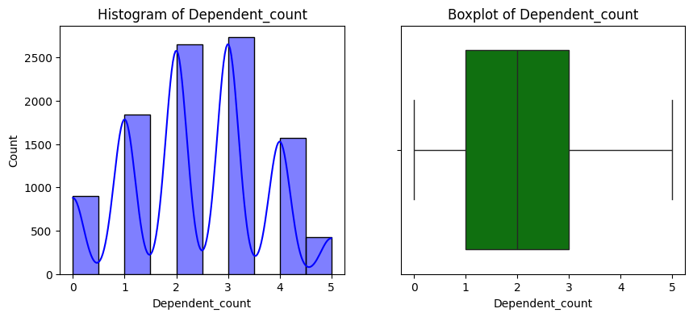

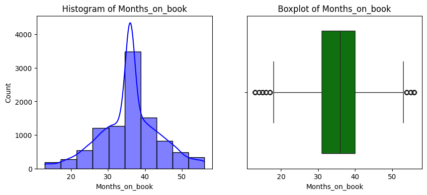

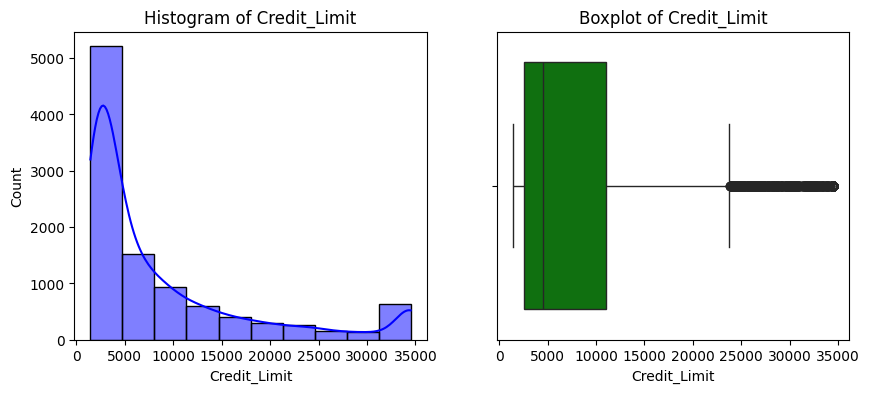

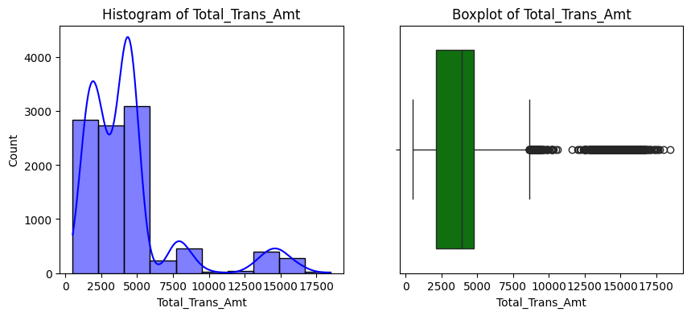

```python
# Univariate Analysis
features = ["Customer_Age", "Dependent_count", "Months_on_book", "Credit_Limit", "Total_Trans_Amt"]

for feature in features:
    plt.figure(figsize=(10, 4))
    # Histogram
    plt.subplot(1, 2, 1)
    sns.histplot(df[feature], bins=10, kde=True, color='blue')
    plt.title(f'Histogram of {feature}')
    # Box Plot
    plt.subplot(1, 2, 2)
    sns.boxplot(x=df[feature], color='green')
    plt.title(f'Boxplot of {feature}')
    plt.show()
```

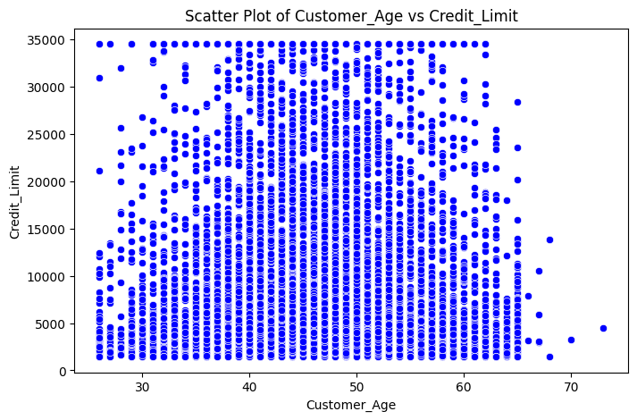

```
Correlation between Customer_Age and Credit_Limit: 0.00
--------------------------------------------------
```

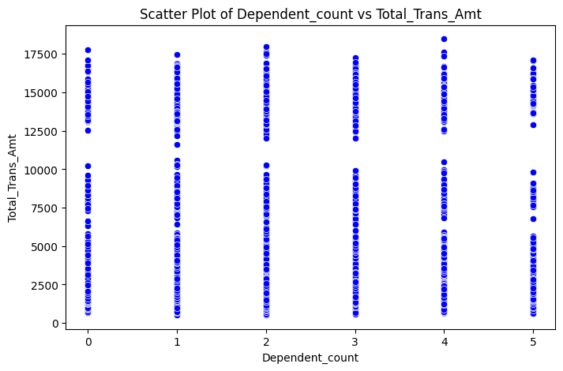

```
Correlation between Dependent_count and Total_Trans_Amt: 0.03
--------------------------------------------------
```

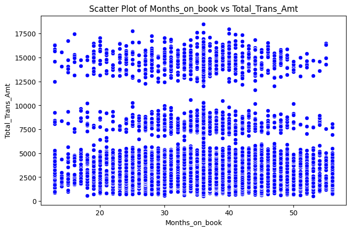

```
Correlation between Months_on_book and Total_Trans_Amt: -0.04
--------------------------------------------------
```

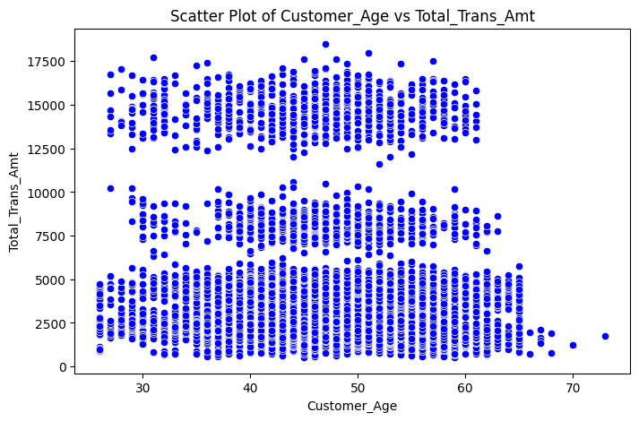

```
Correlation between Customer_Age and Total_Trans_Amt: -0.05
--------------------------------------------------
```

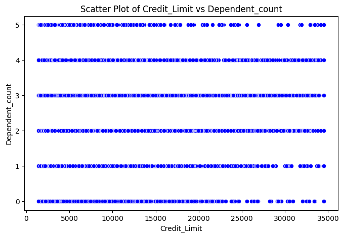

```
Correlation between Credit_Limit and Dependent_count: 0.07
--------------------------------------------------
```

```python
# Bivariate Analysis
feature_pairs = [("Customer_Age", "Credit_Limit"), ("Dependent_count", "Total_Trans_Amt"),
                 ("Months_on_book", "Total_Trans_Amt"), ("Customer_Age", "Total_Trans_Amt"),
                 ("Credit_Limit", "Dependent_count")]
for x_feature, y_feature in feature_pairs:
    plt.figure(figsize=(8, 5))
    sns.scatterplot(x=df[x_feature], y=df[y_feature], color='blue')
    plt.title(f'Scatter Plot of {x_feature} vs {y_feature}')
    plt.xlabel(x_feature)
    plt.ylabel(y_feature)
    plt.show()
    # Correlation
    corr_value = df[[x_feature, y_feature]].corr().iloc[0, 1]
    print(f"Correlation between {x_feature} and {y_feature}: {corr_value:.2f}")
    print("-" * 50)
```

**Univariate Analysis :**

**outlier detection :**

```python
# Outlier Detection and Treatment
for column in df.select_dtypes(include=[np.number]).columns:
    Q1 = df[column].quantile(0.25)
    Q3 = df[column].quantile(0.75)
    IQR = Q3 - Q1
    lower_bound = Q1 - 1.5 * IQR
    upper_bound = Q3 + 1.5 * IQR

    outliers = df[(df[column] < lower_bound) | (df[column] > upper_bound)]
    print(f"Outliers in {column}:", len(outliers))

df[column] = np.where(df[column] < lower_bound, lower_bound, df[column])
df[column] = np.where(df[column] > upper_bound, upper_bound, df[column])
# Feature Engineering
df["Credit_Utilization"] = df["Total_Trans_Amt"] / df["Credit_Limit"]
print("\nFeature Engineering - Credit Utilization Ratio Added:")
print(df.head())
# Handle categorical variables
df = pd.get_dummies(df, drop_first=True)
categorical_features = df.select_dtypes(include=['object']).columns
encoder = ce.OneHotEncoder(cols=categorical_features, handle_unknown='ignore')
df_encoded = encoder.fit_transform(df)
# Train-test split
X = df_encoded.drop(columns=["Total_Trans_Amt"])
y = df_encoded["Total_Trans_Amt"]
X_train, X_test, y_train, y_test = train_test_split(X, y, test_size=0.2, random_state=42)
print("\nTrain-test split completed:")
print("Training data size:", X_train.shape)
print("Testing data size:", X_test.shape)
```

```
Outliers in CLIENTNUM: 0
Outliers in Customer_Age: 2
Outliers in Dependent_count: 0
Outliers in Months_on_book: 386
Outliers in Total_Relationship_Count: 0
Outliers in Months_Inactive_12_mon: 331
Outliers in Contacts_Count_12_mon: 629
Outliers in Credit_Limit: 984
Outliers in Total_Revolving_Bal: 0
Outliers in Avg_Open_To_Buy: 963
Outliers in Total_Amt_Chng_Q4_Q1: 396
Outliers in Total_Trans_Amt: 896
Outliers in Total_Trans_Ct: 2
Outliers in Total_Ct_Chng_Q4_Q1: 394
Outliers in Avg_Utilization_Ratio: 0

Feature Engineering - Credit Utilization Ratio Added:
   CLIENTNUM     Attrition_Flag  Customer_Age Gender  Dependent_count  \
0  768805383  Existing Customer            45      M                3
1  818770008  Existing Customer            49      F                5
2  713982108  Existing Customer            51      M                3
3  769911858  Existing Customer            40      F                4
4  709106358  Existing Customer            40      M                3

  Education_Level Marital_Status Income_Category Card_Category  \
0     High School        Married     $60K - $80K          Blue
1        Graduate         Single  Less than $40K          Blue
2        Graduate        Married    $80K - $120K          Blue
3     High School            NaN  Less than $40K          Blue
4      Uneducated        Married     $60K - $80K          Blue

   Months_on_book  ...  Contacts_Count_12_mon  Credit_Limit  \
0              39  ...                      3       12691.0
1              44  ...                      2        8256.0
2              36  ...                      0        3418.0
3              34  ...                      1        3313.0
4              21  ...                      0        4716.0

   Total_Revolving_Bal  Avg_Open_To_Buy  Total_Amt_Chng_Q4_Q1  \
0                  777          11914.0                 1.335
```

[output cut: 9 more lines]

```
3             1171              20                2.333
4              816              28                2.500

   Avg_Utilization_Ratio  Credit_Utilization
0                  0.061            0.090143
1                  0.105            0.156371
2                  0.000            0.552077
3                  0.760            0.353456
4                  0.000            0.173028

[5 rows x 22 columns]

Train-test split completed:
Training data size: (8101, 32)
Testing data size: (2026, 32)
```

```python
# Define models
models = {
    "Decision Tree": DecisionTreeRegressor(),
    "Random Forest": RandomForestRegressor(n_estimators=100, random_state=42),
    "Gradient Boosting": GradientBoostingRegressor(n_estimators=100, random_state=42),
    "AdaBoost": AdaBoostRegressor(n_estimators=100, random_state=42),
    "Bagging Regressor": BaggingRegressor(n_estimators=100, random_state=42)
}
# Train and evaluate models
for name, model in models.items():
    model.fit(X_train, y_train)
    y_pred = model.predict(X_test)
    print(f"\n{name} Model Performance:")
    print("Mean Absolute Error:", mean_absolute_error(y_test, y_pred))
    print("Mean Squared Error:", mean_squared_error(y_test, y_pred))
    print("R^2 Score:", r2_score(y_test, y_pred))
```

```
Decision Tree Model Performance:
Mean Absolute Error: 527.4901283316881
Mean Squared Error: 1240035.5384995064
R^2 Score: 0.8913770428473995

Random Forest Model Performance:
Mean Absolute Error: 375.04645113524185
Mean Squared Error: 594258.0470170287
R^2 Score: 0.9479449867567288

Gradient Boosting Model Performance:
Mean Absolute Error: 457.4507654287955
Mean Squared Error: 528441.1559326379
R^2 Score: 0.9537103258282429

AdaBoost Model Performance:
Mean Absolute Error: 1504.0429201239342
Mean Squared Error: 2768490.0956139374
R^2 Score: 0.7574895463099736

Bagging Regressor Model Performance:
Mean Absolute Error: 376.9639042448174
Mean Squared Error: 597251.3291445706
R^2 Score: 0.9476827852744398
```

```python
# Applying RandomOverSampler instead of SMOTE
ros = RandomOverSampler(sampling_strategy="auto", random_state=42)
X_train, y_train = ros.fit_resample(X_train, y_train)
## models already mentioned in above section
for name, model in models.items():
    model.fit(X_train, y_train)
    print(f"{name} model training completed.")
```

```
Decision Tree model training completed.
Random Forest model training completed.
Gradient Boosting model training completed.
AdaBoost model training completed.
Bagging Regressor model training completed.
```

```python
# Defining hyperparameter distributions
param_dist_rf = {
    'n_estimators': randint(50, 150),
    'max_depth': [None, 10, 20],
    'min_samples_split': randint(2, 5),
    'max_features': ['sqrt', 'log2']
}
param_dist_gb = {
    'n_estimators': randint(50, 150),
    'learning_rate': [ 0.05, 0.1],
    'max_depth': [3, 5],
    'subsample': [0.8, 1.0]
}
param_dist_ab = {
    'n_estimators': randint(50, 150),
    'learning_rate': [0.05, 0.1],
    'estimator': [DecisionTreeRegressor(max_depth=1)],
}
# Initializing the models
rf = RandomForestRegressor(random_state=42)
gb = GradientBoostingRegressor(random_state=42)
ab = AdaBoostRegressor(random_state=42)
# Performing RandomizedSearchCV
random_rf = RandomizedSearchCV(rf, param_distributions=param_dist_rf, n_iter=10, cv=3, scoring='r2', n_jobs=4, random_state=42)
random_gb = RandomizedSearchCV(gb, param_distributions=param_dist_gb, n_iter=10, cv=3, scoring='r2', n_jobs=4, random_state=42)
random_ab = RandomizedSearchCV(ab, param_distributions=param_dist_ab, n_iter=10, cv=3, scoring='r2', n_jobs=4, random_state=42)
random_rf.fit(X_train, y_train)
random_gb.fit(X_train, y_train)
random_ab.fit(X_train, y_train)
print("Best parameters for Random Forest:", random_rf.best_params_)
print("Best parameters for Gradient Boosting:", random_gb.best_params_)
print("Best parameters for AdaBoost:", random_ab.best_params_)
best_rf = random_rf.best_estimator_
best_gb = random_gb.best_estimator_
best_ab = random_ab.best_estimator_
# Evaluating on test set
for name, model in [("Random Forest", best_rf), ("Gradient Boosting", best_gb), ("AdaBoost", best_ab)]:
    y_pred = model.predict(X_test)
    print(f"\n{name} Model Performance after Tuning:")
    print("Mean Absolute Error:", mean_absolute_error(y_test, y_pred))
    print("Mean Squared Error:", mean_squared_error(y_test, y_pred))
    print("R^2 Score:", r2_score(y_test, y_pred))
```

```
Best parameters for Random Forest: {'max_depth': None, 'max_features': 'log2', 'min_samples_split': 2, 'n_estimators': 98}
Best parameters for Gradient Boosting: {'learning_rate': 0.1, 'max_depth': 5, 'n_estimators': 87, 'subsample': 1.0}
Best parameters for AdaBoost: {'estimator': DecisionTreeRegressor(max_depth=1), 'learning_rate': 0.05, 'n_estimators': 101}

Random Forest Model Performance after Tuning:
Mean Absolute Error: 514.6012601486794
Mean Squared Error: 744596.0665682344
R^2 Score: 0.9347758801068681

Gradient Boosting Model Performance after Tuning:
Mean Absolute Error: 349.68889050498956
Mean Squared Error: 333224.442857642
R^2 Score: 0.9708106556183678

AdaBoost Model Performance after Tuning:
Mean Absolute Error: 1639.7808196777767
Mean Squared Error: 4574046.009021744
R^2 Score: 0.5993288996755718
```

# Comparison of Tuned Model Performances

~ **Gradient Boosting**: **Best performance with the lowest MAE , MSE, and highest R²** .

~ **Random Forest**: **Good performance but slightly weaker than GB**, **with MAE, MSE,and R²**.

~ **AdaBoost**: **Weakest performance with MAE, MSE, and R², making it unsuitable for this task**.

# **~ Model Selection** :

**Model choosen** : **Gradient Boosting**

*REASON* :

**~ Explains 97% of the variance in the dataset (R² = 0.97)**.

**~ Lowest MAE & MSE, meaning more precise predictions**.

**~ Captures non-linear relationships better than Random Forest & AdaBoost**.

**~ Less prone to overfitting compared to a plain Decision Tree** .

# **Analysis** **:**

**~** **Use Gradient Boosting for Best Accuracy Since Gradient Boosting achieved the lowest error and highest R² score , it should be the primary choice for prediction tasks**.  
~ **Consider Random Forest for Faster Predictions Random Forest is slightly less accurate but computationally faster than Gradient Boosting**.  
**~** **Avoid AdaBoost Without Further Improvements AdaBoost performed poorly , indicating it does not handle the dataset well**

# Business recommendations :

- **Focus on High-Value Customers with higher transaction amounts and should be prioritized for loyalty programs and premium services**.
- **Customers with low engagement should receive personalized offers, cashback, or reminders to increase usage** .
- **Provide easy-to-access insights into spending habits, helping customers manage finances better**